# ENFERMEDADES CARDIOVASCULARES Y CLIMA

Nuria Martinez Queralt y Alba Sanz González

2022-12-07

# 1. Relación comunidades autónomas con defunción por enfermedades cardiacas

A partir de los datos obtenidos en la siguiente gráfica, donde se incluye las comunidades autónomas, el año, la causa de defunción y el número total de defunciones por año y comunidad autónoma, se pueden obtener gráficos donde se relacionan dichas variables para sacar más información.

|  | Causa_Defuncion | ComunidadesAutónomas | fecha | Total |
| --- | --- | --- | --- | --- |
| 1 | Enfermedades cardiovasculares | ANDALUCIA | 2020 | 26531 |
| 2 | Enfermedades cardiovasculares | ANDALUCIA | 2019 | 25109 |
| 3 | Enfermedades cardiovasculares | ANDALUCIA | 2018 | 27011 |
| 4 | Enfermedades cardiovasculares | ARAGON | 2020 | 31057 |
| 5 | Enfermedades cardiovasculares | ARAGON | 2019 | 30658 |
| 6 | Enfermedades cardiovasculares | ARAGON | 2018 | 32621 |
| 7 | Enfermedades cardiovasculares | ASTURIAS | 2020 | 37038 |
| 8 | Enfermedades cardiovasculares | ASTURIAS | 2019 | 37136 |
| 9 | Enfermedades cardiovasculares | ASTURIAS | 2018 | 37903 |
| 10 | Enfermedades cardiovasculares | ISLAS BALEARES | 2020 | 18533 |

[output cut: 47 more lines]

Para poder ver si existe cierta relación entre las comunidades autónomas y muertes por enfermedades cardiovasaculares, se han cogido los datos con respecto a los años 2018, 2019 y 2020 y creado un gráfico de barras y de dipersión.

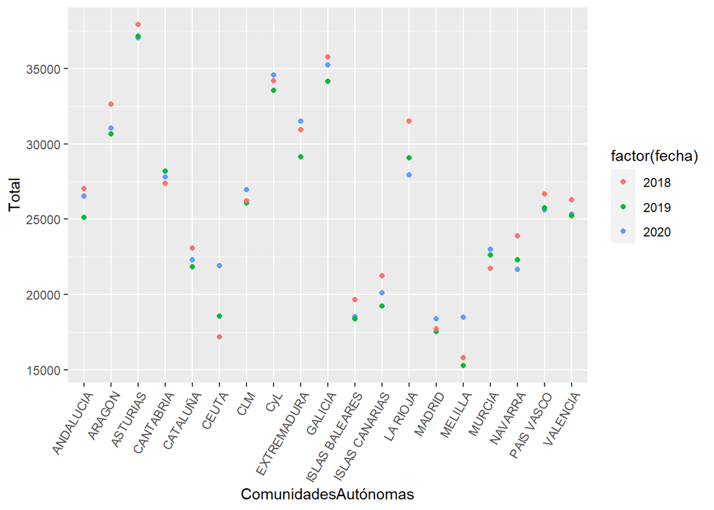

```r
final <-  ggplot(datos, aes(x = ComunidadesAutónomas , y = Total)) +
  geom_point(aes (colour = factor(fecha))) +
  geom_smooth() +
  theme(axis.text.x = element_text(angle = 60, vjust = 1, hjust = 1))
```

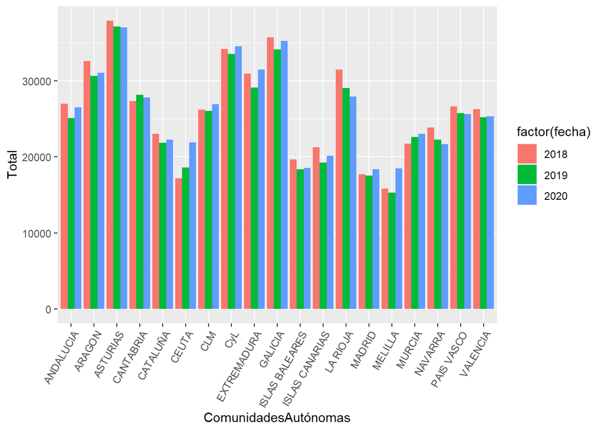

```r
gr_barras <- ggplot(datos, aes( x= ComunidadesAutónomas, y = Total))+
  geom_bar(aes(fill=factor(fecha)), stat = 'identity', position = 'dodge')+
  theme(axis.text.x = element_text(angle = 60, vjust = 1, hjust = 1))
```

Aparte, en la págine INE, de donde vienen los datos, se han cogido las imágenes del mapa de España con respecto a cada año teniendo una idea más visual geográficamente de los cambios q ha habido.

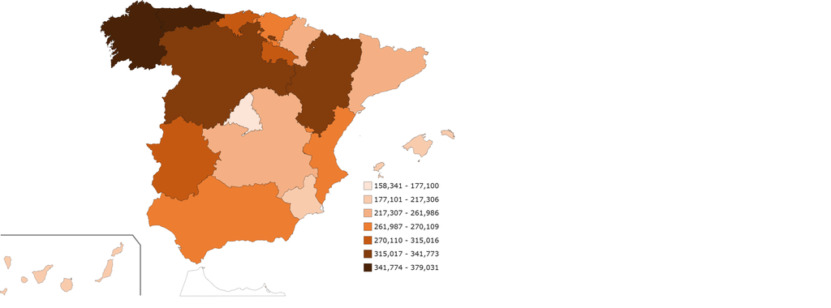

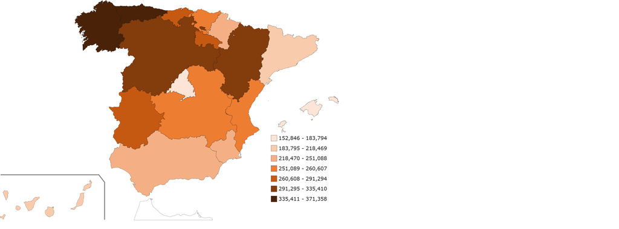

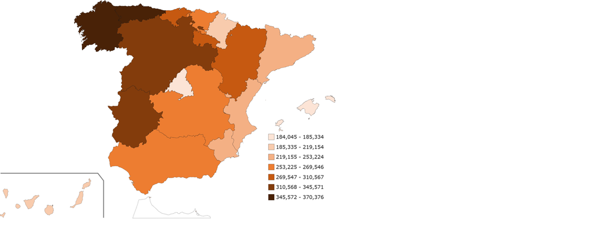

**Conclusión:** Se puede observar que ha habido un incremento de muertes en la zona sur y centro oeste mientras que en la zona noreste se aprecia una disminución

# 2. Relación temperaturas máx y mín por Comuniades

A partir de los datos obtenidos en la siguiente gráfica, donde se incluye las comunidades autónomas, el año, la temperatura máxima y la mínima se pueden obtener gráficos donde se relacionan dichas variables para sacar más información.

|  | ComunidadesAutónomas | tmax | tmin | fecha |
| --- | --- | --- | --- | --- |
| 1 | ANDALUCIA | 22.4215791014196 | 11.8016097168362 | 2018 |
| 2 | ARAGON | 19.6291238173591 | 7.7458864664747 | 2018 |
| 3 | ASTURIAS | 16.5224890829694 | 9.32331422331422 | 2018 |
| 4 | CANTABRIA | 17.5766343825666 | 9.89495560936239 | 2018 |
| 5 | CATALUÑA | 20.4835922183683 | 9.95367913148372 | 2018 |
| 6 | CEUTA | 21.6843835616438 | 15.5547945205479 | 2018 |
| 7 | CLM | 20.5676706544687 | 8.176593947924 | 2018 |
| 8 | CyL | 17.4302898396857 | 5.78134296642584 | 2018 |
| 9 | EXTREMADURA | 22.5927741635688 | 10.4657760223048 | 2018 |
| 10 | GALICIA | 18.3631915694392 | 9.48652615732029 | 2018 |

[output cut: 47 more lines]

Relacionando los datos de la temperatura máxima y mínima, mediante distintos gráficos, se puede observar como varía la temperatura en función de la comunidad autónoma.

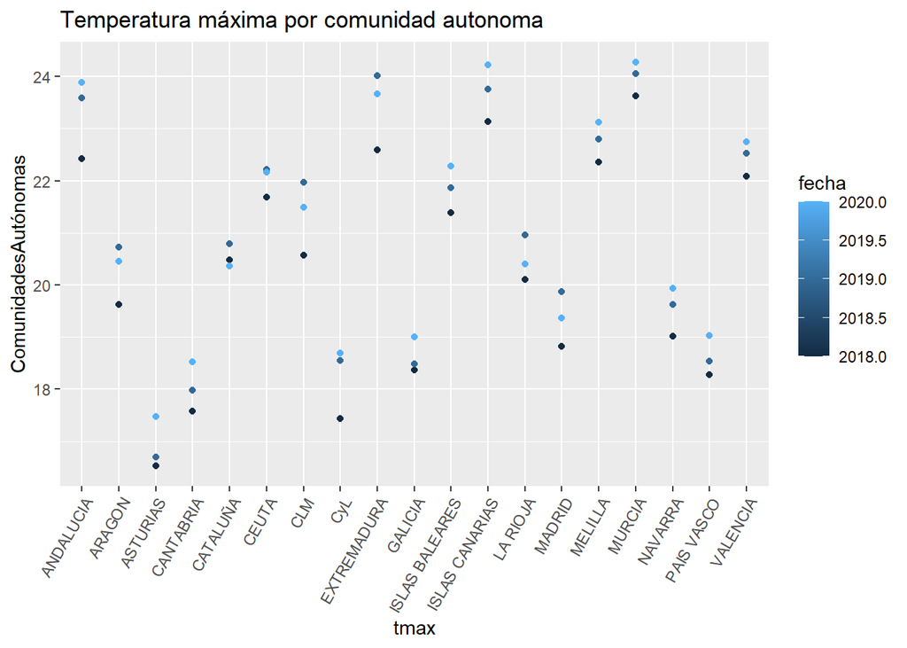

```r
  ggplot(data = tabladefinitiva, aes(x =ComunidadesAutónomas , y = tmax))+
  geom_point(aes(colour = fecha))+
  labs(x = "tmax", y = "ComunidadesAutónomas",title = 'Temperatura máxima por comunidad autonoma')+
  theme(axis.text.x = element_text(angle = 60, vjust = 1, hjust = 1))
```

En este primer gráfico de puntos, se observa la temperatura máxima por comunidad autónoma entre 2018 y 2020, y se puede ver que en muchas comunidades la temperatura máxima ha aumentado a lo largo del tiempo.

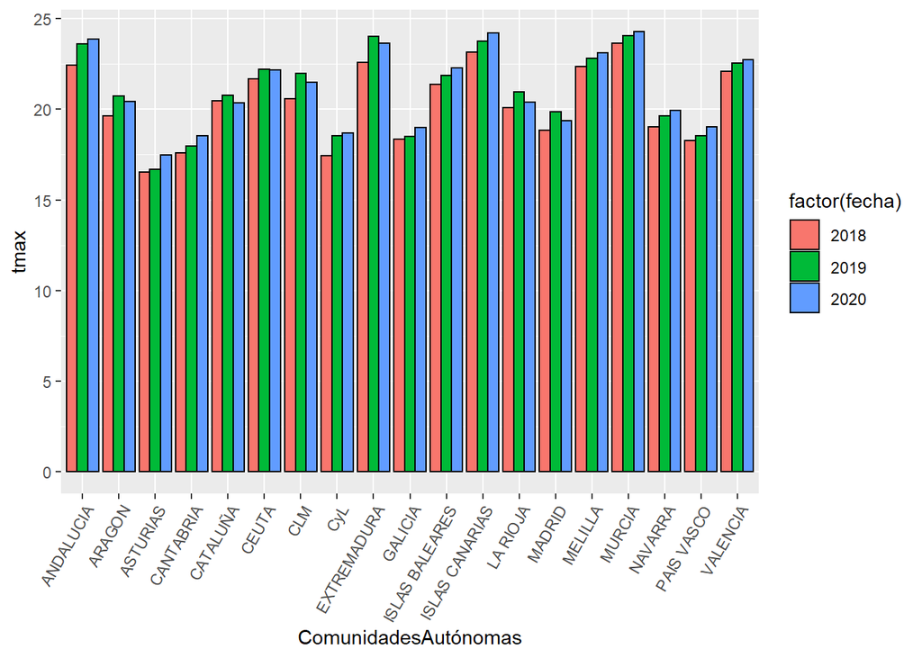

```r
  ggplot(tabladefinitiva, aes(x = ComunidadesAutónomas, y = tmax )) +
  geom_bar(stat = 'identity', aes(fill = factor(fecha)), colour ='black',position = 'dodge') +
  theme(axis.text.x = element_text(angle = 60, vjust = 1, hjust = 1))
```

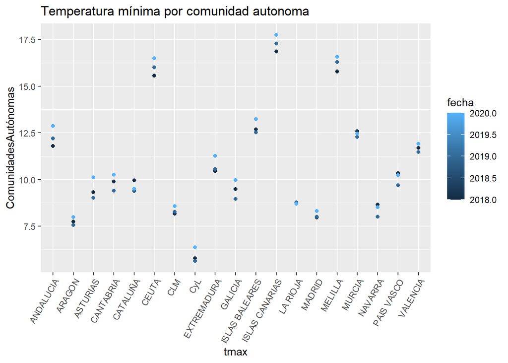

```r
  ggplot(data = tabladefinitiva, aes(x =ComunidadesAutónomas , y = tmin))+
  geom_point(aes(colour = fecha))+
  labs(x = "tmax", y = "ComunidadesAutónomas",title = 'Temperatura mínima por comunidad autonoma')+
  theme(axis.text.x = element_text(angle = 60, vjust = 1, hjust = 1))
```

En este gráfico de puntos, se observa la temperatura minima por comunidad autónoma entre 2018 y 2020, y se puede ver que, existe mucha diferencia en la temperatura mínima entre unas comunidades y otras. A su vez, también se aprecia una subida de temperatura en prácticamente todas las comunidades en el último año.

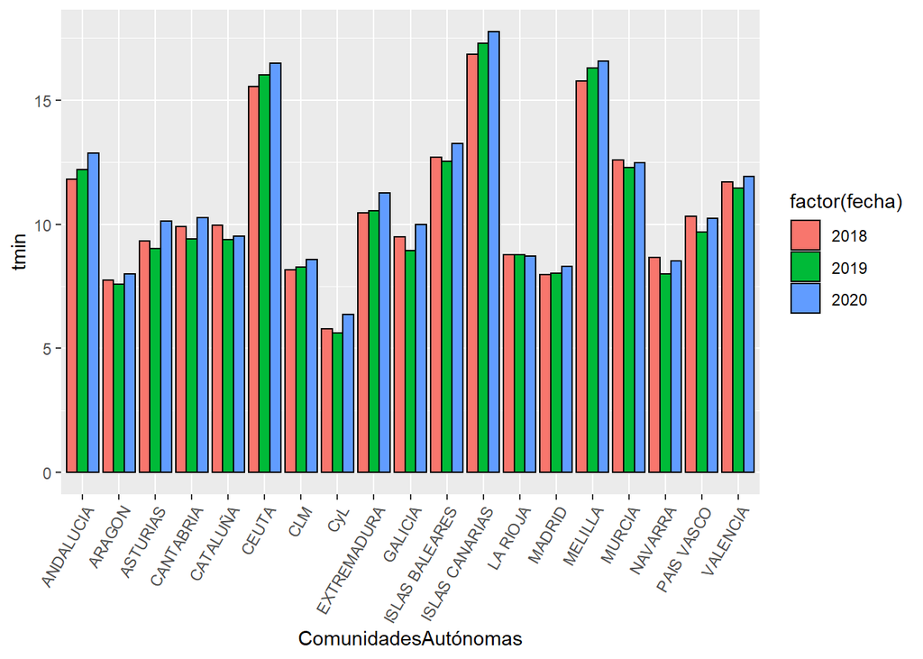

```r
  ggplot(tabladefinitiva, aes(x = ComunidadesAutónomas, y = tmin )) +
  geom_bar(stat = 'identity', aes(fill = factor(fecha)), colour ='black',position = 'dodge') +
  theme(axis.text.x = element_text(angle = 60, vjust = 1, hjust = 1))
```